# Annex - The Brazilian Electric System Green Transition seen from a Dependency perspective v1.1

Rafael da Costa

2024-08-28

This Research Briefing Annex contains all data used in the text **The Brazilian Electric System Green Transition seen from a Dependency perspective** presented to the organisation of the **Workshop on Green energy transitions and global disruption: The (un)just transition to Net Zero**, to be held at the University of Manchester, UK on 11-13 September 2024.

This version contains only raw datasets. Some calculations used in the paper are still missing.

Author’s contact: Rafael.Da-Silva-Da-costa@warwick.ac.uk

**Warning**: *To access Brazilian federal government open data links provided here you must first setup a VPN with a Brazilian IP mask*.

# Data on electricity distribution per Brazilian municipalities

## Table 1 - GDP, Total Population and Energy Distribution Company per Municipality:

- *This dataset contains more observations (6857) than there are Brazilian municipalities (5572)*. Since more than one energy distribution company serves certain municipalities, they generate more than one observation.
- *The intention was to identify the energy distribution’s controller to highlight the concentration existing in the Brazilian Electricity market*.

**Complete dataset**:

| Municipality | mun_code | State | Distribution_Company | Company_Controller | Population | GDP |
| --- | --- | --- | --- | --- | --- | --- |
| Alvarães | 1300029 | AM | AME | Unidentified | 15916 | 217333 |
| Amaturá | 1300060 | AM | AME | Unidentified | 10814 | 118872 |
| Anamã | 1300086 | AM | AME | Unidentified | 9927 | 138599 |
| Anori | 1300102 | AM | AME | Unidentified | 17052 | 248435 |
| Apuí | 1300144 | AM | AME | Unidentified | 21403 | 297810 |
| Atalaia do Norte | 1300201 | AM | AME | Unidentified | 15440 | 184947 |
| Autazes | 1300300 | AM | AME | Unidentified | 41672 | 506341 |
| Barcelos | 1300409 | AM | AME | Unidentified | 18399 | 245622 |
| Barreirinha | 1300508 | AM | AME | Unidentified | 30990 | 344890 |
| Benjamin Constant | 1300607 | AM | AME | Unidentified | 37436 | 388781 |

[output cut: 6847 more lines]

**Sources**: Instituto Brasileiro de Geografia e Estatística - IBGE, Municipalities Gross Domestic Product, retrieved 28 August 2024 from https://ftp.ibge.gov.br/Pib_Municipios/2021/base/base_de_dados_2010_2021_xlsx.zip; Agência Nacional de Energia Elétrica - Aneel, Reports Portal, retrieved 28 August 2024 from https://www2.aneel.gov.br/relatoriosrig/(S(gcwd12tr2undw15hdx3vkbjv))/relatorio.aspx?folder=sfe&report=DistribuidoradecadaMunicipio

### Image 1 - Share of GDP by distribution controller

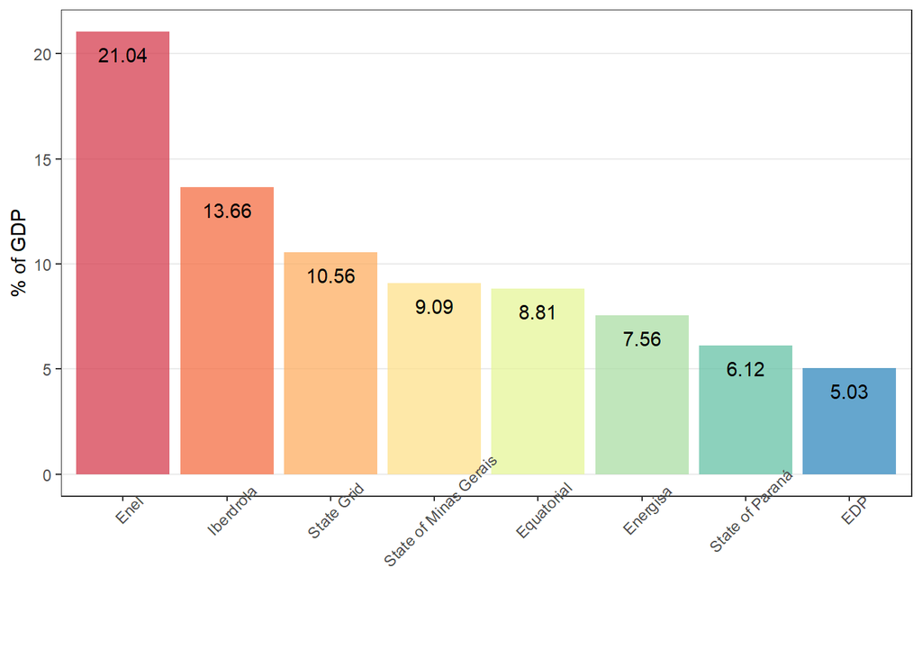

### Image 2 - Share of Brazilian Population by distribution controller

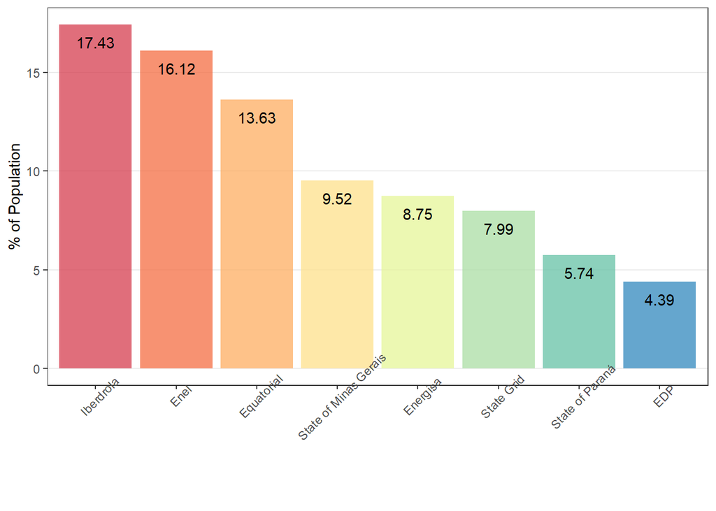

## Table 2 - Brazilian Energy Generation Plants

**Complete dataset**:

| Reference_Date | Plant_Name | BR_Region | Type_Energy_Source | MW_Generated_Monthly |
| --- | --- | --- | --- | --- |
| 2024-06-01 | FURNAS COTAS | Southeast | Hydro | 62.496285 |
| 2024-06-01 | FURNAS FURNAS | Southeast | Hydro | 39.166453 |
| 2024-06-01 | PEIXOTO | Southeast | Hydro | 81.815554 |
| 2024-06-01 | ESTREITO(FURNAS)COTA | Southeast | Hydro | 143.525218 |
| 2024-06-01 | CARLOS BARRETO LIVRE | Southeast | Hydro | 47.841739 |
| 2024-06-01 | PORTO COLOMBIA COTA | Southeast | Hydro | 50.848707 |
| 2024-06-01 | PORTO COLÔMBIA | Southeast | Hydro | 33.899138 |
| 2024-06-01 | MARIMBONDO COTA | Southeast | Hydro | 204.722032 |
| 2024-06-01 | MARIMBONDO FURNAS | Southeast | Hydro | 136.481355 |
| 2024-06-01 | ITUMBIARA (FURNAS) | Southeast | Hydro | 212.588467 |

[output cut: 9990 more lines]

**Source**: Câmara de Comercialização de Energia Elétrica - CCEE, retrieved 28 August 2024 from https://pda-download.ccee.org.br/7gQCl3h9Ru6ORLv5SyddeA/content

### Image 3 - MW genereted by Brazilian Electricity Power Plants in June, 2024, by energy source

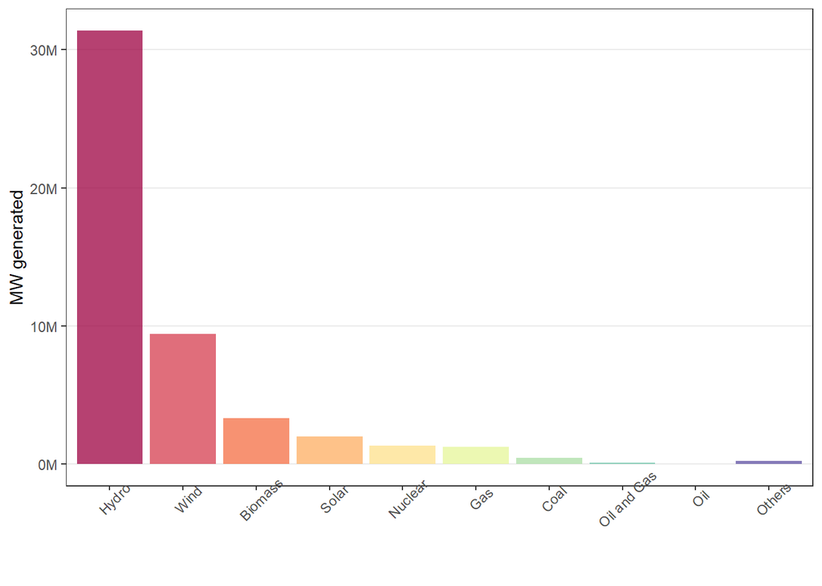

*After identifying the 90th percentile of energy generation plants, the research looked for the companies owning them*. The result of this investigation is as follows:

| SIGLA_USINA | MW_Generated_Monthly | owner | energy |
| --- | --- | --- | --- |
| ITAIPU | 3257873.540467 | Brazilian Federal Government | hydro |
| TUCURUI | 2205574.374857 | Eletrobras-Eletronorte | hydro |
| S ANTONIO (STOANT) | 1040321.521274 | Eletrobras | hydro |
| BELO MONTE | 1006857.898632 | Eletrobras-Eletronorte | hydro |
| ITA | 853812.128808 | Engie Brasil | hydro |
| GOV. BENTO MUNHOZ | 738845.611237 | Copel-Undisclosed Private Investor | hydro |
| MACHADINHO | 710057.875769 | Engie Brasil | hydro |
| SALTO SANTIAGO | 632382.077725 | Engie Brasil | hydro |
| SALTO CAXIAS (GJR) | 614382.031950 | Engie Brasil | hydro |
| JIRAU | 578817.469939 | Eletrobas-Engie Brasil | hydro |

[output cut: 171 more lines]

## Table 3 - Brazilian Energy Transmission Auctions Results

*All monetary values in the variable* **Predicted_Investment** *are the investment’s real values in Brazilian Reais (BRL) at December/2023, adjusted by inflation*.

**Complete dataset**:

| Auction_Year | Auction_Date | Auction_Number | Predicted_Investment |
| --- | --- | --- | --- |
| 1999 | 1999-12-03 | 007/1999 | 892184840.6361 |
| 2000 | 2000-02-14 | 004/2000 | 2640643472.7010 |
| 2000 | 2000-02-14 | 004/2000 | 659482867.4120 |
| 2000 | 2000-02-14 | 004/2000 | 1745936715.4860 |
| 2000 | 2000-03-15 | 011/1999 | 661884440.3901 |
| 2000 | 2000-04-04 | 003/2000 | 317758971.2658 |
| 2000 | 2000-08-31 | 002/2000 | 1062423536.1022 |
| 2000 | 2000-08-31 | 002/2000 | 2683926093.1843 |
| 2000 | 2000-08-31 | 002/2000 | 2938777281.8203 |
| 2001 | 2001-06-12 | 001/2001 | 114853251.9806 |

[output cut: 457 more lines]

Source: Electric Energy National Agency - Aneel, Reports Portal, retrieved 28 August 2024 from https://dadosabertos.aneel.gov.br/dataset/593537c6-9e0e-4ed9-817a-2c5d5de05147/resource/453cb742-8089-4c16-aaf2-42088b5553dc/download/resultado-leiloes-transmissao.csv

| Year | MW_Installed | growth_rate |
| --- | --- | --- |
| 1999 | 67946.00 | NA |
| 2000 | 72299.00 | 6.41 |
| 2001 | 74876.00 | 3.56 |
| 2002 | 80314.90 | 7.26 |
| 2003 | 83807.25 | 4.35 |
| 2004 | 88629.01 | 5.75 |
| 2005 | 92865.52 | 4.78 |
| 2006 | 96294.46 | 3.69 |
| 2007 | 100352.44 | 4.21 |
| 2008 | 102609.72 | 2.25 |

[output cut: 14 more lines]

Source: Empresa de Pesquisa Energética - EPE, Balanço Energético Nacional 2024, retrieved 28 August 2024 from https://dadosabertos.aneel.gov.br/dataset/4bf07812-e421-48f3-8e48-eec0040764ba/resource/3b3eb013-8831-4ca9-a582-01010ff4e0fb/download/acrescimo-anual-potencia-instalada.csv

## Table 5 - Brazilian Wind Tech Imports

*To identify Brazilian Wind Tech imports the research used the* **Mercosul Common Nomenclature**, *which is the standard registry used in Brazil to single out import and export goods*.*According to this standard registry, wind tech imports fall under the number* **8502 - Wind-power Generating Sets**.

**Complete dataset**:

| Year | Importer | VL_FOB | Share_of_Imports |
| --- | --- | --- | --- |
| 1997 | China | 16034 | 0.04 |
| 1997 | EU | 31218982 | 70.88 |
| 1997 | Others | 5884863 | 13.36 |
| 1997 | United States | 6925923 | 15.72 |
| 1998 | China | 31532 | 0.02 |
| 1998 | EU | 134077148 | 73.37 |
| 1998 | Others | 11222446 | 6.14 |
| 1998 | United States | 37408487 | 20.47 |
| 1999 | China | 3960474 | 1.24 |
| 1999 | EU | 127011354 | 39.61 |

[output cut: 102 more lines]

Source: Ministério do Desenvolvimento, Indústria e Comércio Exterior - MDIC, Comexstat, retrieved 28 August 2024 from [https://balanca.economia.gov.br/balanca/bd/comexstat-bd/mun/IMP_COMPLETA_MUN.zip”](https://balanca.economia.gov.br/balanca/bd/comexstat-bd/mun/IMP_COMPLETA_MUN.zip%22)

## Table 6 - Brazilian Solar Tech Imports

| Year | Importer | VL_FOB | Share_of_Imports |
| --- | --- | --- | --- |
| 1997 | China | 1961977 | 0.99 |
| 1997 | EU | 27761971 | 13.99 |
| 1997 | Others | 102606806 | 51.71 |
| 1997 | United States | 66079859 | 33.30 |
| 1998 | China | 2984076 | 1.38 |
| 1998 | EU | 28396842 | 13.18 |
| 1998 | Others | 102278475 | 47.47 |
| 1998 | United States | 81814916 | 37.97 |
| 1999 | China | 10790574 | 4.24 |
| 1999 | EU | 20565904 | 8.09 |

[output cut: 102 more lines]

Source: Ministério do Desenvolvimento, Indústria e Comércio Exterior - MDIC, Comexstat, retrieved 28 August 2024 from [https://balanca.economia.gov.br/balanca/bd/comexstat-bd/mun/IMP_COMPLETA_MUN.zip”](https://balanca.economia.gov.br/balanca/bd/comexstat-bd/mun/IMP_COMPLETA_MUN.zip%22)